# **HW3 for Nonlinear Control Systems**

> Instructor: Dr. Le Yi Wang  
> **Solutions given by Yuqi Wang**  
> Email: he1173@wayne.edu

## Descriptions

- Source code was uploaded to [Github repo](https://github.com/BoomAmplifier/NLS-HW.git).
- *Jupyter Notebook* and *python3* are used in the solutions.

[figure not shown]

Jupyter Notebook support list:

- Markdown
- $\LaTeX$
- Python
- Slides
- ...

[figure not shown]

Python3 packages

- NumPy: scientific computing
- matplotlib: visualizations
- SymPy: symbolic mathematics

#### Problem 3:

Determine regions of attraction of the pendulum, using as Lyapunov functions the pendulum's total energy, and the modified Lyapunov function of p67. Comment on the two results.

[figure not shown]

**Solution:**
The system is described by $$\ddot{\theta}+\dot{\theta}+\sin{\theta}=0$$

Lyapunov functions are
$$ \begin{equation} \tag{3-1} \left\{ \begin{array}{} V_1(x)= (1-\cos{\theta})+\frac{\dot{\theta}^2}{2} \\ V_2(x)= \frac{1}{2} \dot{\theta}^2+\frac{1}{2}(\dot{\theta}+\theta)^2+2(1-\cos{\theta}) \end{array} \right. \end{equation} $$ Obviously, $$\lim\limits_{|\theta|\to\infty}V_{1,2}=\infty$$
Correspondingly, $$ \begin{equation} \tag{3-2} \left\{ \begin{array}{} \dot{V}_1(x)= -\dot{\theta}^2 \\ \dot{V}_2(x)= -(\dot{\theta}^2+\theta \sin{\theta}) \end{array} \right. \end{equation} $$

For $$V_1=(1-\cos{\theta})+\frac{\dot{\theta}^2}{2} $$

$$\dot{V}_1(x)=-\dot{\theta}^2< 0$$

while $|x|\neq 0$.

Thus, $\dot{V}_1(x)$ is negative semi-definite.

The system is local stable at origin.

For $$V_2=\frac{1}{2} \dot{\theta}^2+\frac{1}{2}(\dot{\theta}+\theta)^2+2(1-\cos{\theta}) $$

$$\dot{V}_2(x) = -(\dot{\theta}^2+\theta \sin{\theta}) $$

let $\theta \sin{\theta}=0$, $\theta=0,\pi,2\pi...n\pi$

```python
import numpy as np
import matplotlib.pyplot as plt
from matplotlib.patches import Ellipse, Circle
from sympy import *
import pylab as plb
from ipywidgets import interact, interactive, fixed, interact_manual
import ipywidgets as widgets
%matplotlib inline
```

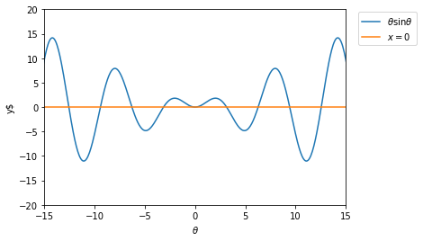

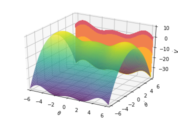

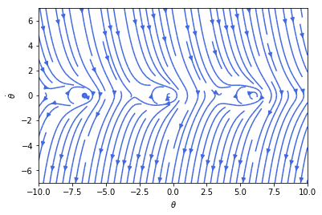

Above all,

1. $\theta \in (\pm2k\pi,\pm(2k+1)\pi) \Rightarrow \theta \sin{\theta} >0, \dot{V}_2(x) \leq 0 $.  
   The system is stable at those equilibrum points.
2. $\theta \in (\pm(2k+1)\pi,\pm 2(k+1)\pi) \Rightarrow \theta \sin{\theta} <0, \exists \theta: V_2>0$.  
   The system is unstable at those equilibrum points.  
   (*where k is a positive integer.*)

Rigorously, in real physical world, $\theta$ in a pendulum system only could be $\pm \pi$. The system is stable.

[figure not shown]